# Project: Medical Appointment No Shows

- Introduction
- Data Wrangling
- Exploratory Data Analysis
- Conclusions

## Introduction

### Dataset Description

This dataset collects information from 100k medical appointments in Brazil and is focused on the question of whether or not patients show up for their appointment. A number of characteristics about the patient are included in each row.

### Explanation of each column :

- PatientId — Identification of a patient
- AppointmentID — Identification of each appointment
- Gender — Male or Female
- ScheduledDay — The day someone called or registered the appointment, this is before appointment Day.
- AppointmentDay — The day of the actuall appointment, when they have to visit the doctor.
- Age — How old is the patient.
- Neighbourhood — indicates the location of the hospital.
- Scholarship — indicates whether or not the patient is enrolled in Brasilian welfare program Bolsa Família.
- Hipertension — True or False
- Diabetes True or False
- Alcoholism True or False
- Handcap True or False
- SMS_received — 1 if messages sent to the patient else 0.
- No-show — "No" if the patient showed up to their appointment, "Yes" if they did not show up.

### Questions for Analysis

- Question 1: How many patients attend and who missed the appointment ?
- Question 2: How many patients attend missed the appointment according to the gender?
- Question 3: Which age is the most common for showing up and for missing the appointment according to the gender?
- Question 4: What factors are important for us to know in order to predict if a patient will show up for their scheduled appointment?

```python
# import important packages
import numpy as np
import pandas as pd
import matplotlib.pyplot as plt
%matplotlib inline
```

## Data Wrangling

```python
#load data
df = pd.read_csv('noshowappointments-kagglev2-may-2016.csv')
df.head()
```

|  | PatientId | AppointmentID | Gender | ScheduledDay | AppointmentDay | Age | Neighbourhood | Scholarship | Hipertension | Diabetes | Alcoholism | Handcap | SMS_received | No-show |
| --- | --- | --- | --- | --- | --- | --- | --- | --- | --- | --- | --- | --- | --- | --- |
| 0 | 2.987250e+13 | 5642903 | F | 2016-04-29T18:38:08Z | 2016-04-29T00:00:00Z | 62 | JARDIM DA PENHA | 0 | 1 | 0 | 0 | 0 | 0 | No |
| 1 | 5.589978e+14 | 5642503 | M | 2016-04-29T16:08:27Z | 2016-04-29T00:00:00Z | 56 | JARDIM DA PENHA | 0 | 0 | 0 | 0 | 0 | 0 | No |
| 2 | 4.262962e+12 | 5642549 | F | 2016-04-29T16:19:04Z | 2016-04-29T00:00:00Z | 62 | MATA DA PRAIA | 0 | 0 | 0 | 0 | 0 | 0 | No |
| 3 | 8.679512e+11 | 5642828 | F | 2016-04-29T17:29:31Z | 2016-04-29T00:00:00Z | 8 | PONTAL DE CAMBURI | 0 | 0 | 0 | 0 | 0 | 0 | No |
| 4 | 8.841186e+12 | 5642494 | F | 2016-04-29T16:07:23Z | 2016-04-29T00:00:00Z | 56 | JARDIM DA PENHA | 0 | 1 | 1 | 0 | 0 | 0 | No |

```python
#check number of rows and columns
df.shape
```

```
(110527, 14)
```

- There is 110527 rows and 14 coulmns

the patientId must be int.

```python
#Information about the dataset
df.info()
```

```
<class 'pandas.core.frame.DataFrame'>
RangeIndex: 110527 entries, 0 to 110526
Data columns (total 14 columns):
 #   Column          Non-Null Count   Dtype
---  ------          --------------   -----
 0   PatientId       110527 non-null  float64
 1   AppointmentID   110527 non-null  int64
 2   Gender          110527 non-null  object
 3   ScheduledDay    110527 non-null  object
 4   AppointmentDay  110527 non-null  object
 5   Age             110527 non-null  int64
 6   Neighbourhood   110527 non-null  object
 7   Scholarship     110527 non-null  int64
 8   Hipertension    110527 non-null  int64
 9   Diabetes        110527 non-null  int64
 10  Alcoholism      110527 non-null  int64
 11  Handcap         110527 non-null  int64
 12  SMS_received    110527 non-null  int64
 13  No-show         110527 non-null  object
dtypes: float64(1), int64(8), object(5)
memory usage: 11.8+ MB
```

- PatientId column should be int, we well modify it in data cleaning section

```python
#check for duplicates in dataset
sum(df.duplicated())
```

```
0
```

- There is no duplicates in the dataset

```python
#check for the missing values
df.isnull().sum()
```

```
PatientId         0
AppointmentID     0
Gender            0
ScheduledDay      0
AppointmentDay    0
Age               0
Neighbourhood     0
Scholarship       0
Hipertension      0
Diabetes          0
Alcoholism        0
Handcap           0
SMS_received      0
No-show           0
dtype: int64
```

- No missing values in our dataset

### We notice here that we have only 62299 of 110527 unique IDs for the patients

```python
df['PatientId'].nunique()
```

```
62299
```

- We notice here that we have only 62299 of 110527 unique IDs for the patients

```python
df['AppointmentID'].nunique()
```

```
110527
```

```python
#check for the duplicates in PatientId column
sum(df['PatientId'].duplicated())
```

```
48228
```

- We have 48228 duplicates for the PatientId

### Here we have 38710 duplicates with the same information so we will remove them.

```python
#check for the duplicates in PatientId and No-show columns with the same information
df.duplicated(['PatientId','No-show']).sum()
```

```
38710
```

- We have 38710 duplicates with the same information so we will remove them in data cleaning section.

```python
#Statistical infromation about the dataset
df.describe()
```

|  | PatientId | AppointmentID | Age | Scholarship | Hipertension | Diabetes | Alcoholism | Handcap | SMS_received |
| --- | --- | --- | --- | --- | --- | --- | --- | --- | --- |
| count | 1.105270e+05 | 1.105270e+05 | 110527.000000 | 110527.000000 | 110527.000000 | 110527.000000 | 110527.000000 | 110527.000000 | 110527.000000 |
| mean | 1.474963e+14 | 5.675305e+06 | 37.088874 | 0.098266 | 0.197246 | 0.071865 | 0.030400 | 0.022248 | 0.321026 |
| std | 2.560949e+14 | 7.129575e+04 | 23.110205 | 0.297675 | 0.397921 | 0.258265 | 0.171686 | 0.161543 | 0.466873 |
| min | 3.921784e+04 | 5.030230e+06 | -1.000000 | 0.000000 | 0.000000 | 0.000000 | 0.000000 | 0.000000 | 0.000000 |
| 25% | 4.172614e+12 | 5.640286e+06 | 18.000000 | 0.000000 | 0.000000 | 0.000000 | 0.000000 | 0.000000 | 0.000000 |
| 50% | 3.173184e+13 | 5.680573e+06 | 37.000000 | 0.000000 | 0.000000 | 0.000000 | 0.000000 | 0.000000 | 0.000000 |
| 75% | 9.439172e+13 | 5.725524e+06 | 55.000000 | 0.000000 | 0.000000 | 0.000000 | 0.000000 | 0.000000 | 1.000000 |
| max | 9.999816e+14 | 5.790484e+06 | 115.000000 | 1.000000 | 1.000000 | 1.000000 | 1.000000 | 4.000000 | 1.000000 |

- I found here the min age with negative value and Handcap column has max value with 4 so it must be 0 or 1 so we will check this.

```python
#check how many values lesss than 0 in Age columns
df[df['Age'] < 0]
```

|  | PatientId | AppointmentID | Gender | ScheduledDay | AppointmentDay | Age | Neighbourhood | Scholarship | Hipertension | Diabetes | Alcoholism | Handcap | SMS_received | No-show |
| --- | --- | --- | --- | --- | --- | --- | --- | --- | --- | --- | --- | --- | --- | --- |
| 99832 | 4.659432e+14 | 5775010 | F | 2016-06-06T08:58:13Z | 2016-06-06T00:00:00Z | -1 | ROMÃO | 0 | 0 | 0 | 0 | 0 | 0 | No |

- Only one raw with negative value

```python
df.query('Handcap == [2,3,4]')
```

|  | PatientId | AppointmentID | Gender | ScheduledDay | AppointmentDay | Age | Neighbourhood | Scholarship | Hipertension | Diabetes | Alcoholism | Handcap | SMS_received | No-show |
| --- | --- | --- | --- | --- | --- | --- | --- | --- | --- | --- | --- | --- | --- | --- |
| 946 | 7.282582e+13 | 5582483 | M | 2016-04-14T09:26:08Z | 2016-04-29T00:00:00Z | 94 | BELA VISTA | 0 | 1 | 1 | 0 | 2 | 1 | No |
| 1665 | 1.242919e+13 | 5525497 | M | 2016-03-30T09:16:41Z | 2016-04-29T00:00:00Z | 64 | SANTA MARTHA | 0 | 1 | 0 | 1 | 2 | 1 | No |
| 1666 | 1.242919e+13 | 5525498 | M | 2016-03-30T09:16:41Z | 2016-04-29T00:00:00Z | 64 | SANTA MARTHA | 0 | 1 | 0 | 1 | 2 | 0 | No |
| 2071 | 1.242919e+13 | 5640120 | M | 2016-04-29T10:08:48Z | 2016-04-29T00:00:00Z | 64 | SANTA MARTHA | 0 | 1 | 0 | 1 | 2 | 0 | No |
| 2091 | 1.491829e+13 | 5638626 | F | 2016-04-29T08:13:59Z | 2016-04-29T00:00:00Z | 11 | ANDORINHAS | 0 | 0 | 0 | 0 | 2 | 0 | No |
| ... | ... | ... | ... | ... | ... | ... | ... | ... | ... | ... | ... | ... | ... | ... |
| 108376 | 2.387212e+14 | 5756931 | F | 2016-06-01T08:48:28Z | 2016-06-07T00:00:00Z | 44 | ROMÃO | 0 | 1 | 1 | 0 | 2 | 1 | No |
| 109484 | 3.589495e+14 | 5752442 | M | 2016-05-31T11:45:57Z | 2016-06-02T00:00:00Z | 64 | DA PENHA | 0 | 1 | 1 | 0 | 2 | 0 | No |
| 109733 | 5.662976e+14 | 5772744 | F | 2016-06-03T16:11:00Z | 2016-06-07T00:00:00Z | 34 | JUCUTUQUARA | 0 | 0 | 0 | 0 | 2 | 1 | No |
| 109975 | 4.522185e+13 | 5766970 | M | 2016-06-02T16:07:36Z | 2016-06-06T00:00:00Z | 39 | PRAIA DO SUÁ | 1 | 0 | 0 | 0 | 2 | 1 | No |
| 110107 | 7.143714e+14 | 5761625 | F | 2016-06-02T06:44:00Z | 2016-06-06T00:00:00Z | 44 | RESISTÊNCIA | 0 | 0 | 0 | 0 | 2 | 1 | No |

199 rows × 14 columns

- There are 199 raw with values different from 0 and 1, we will remove them in data cleaning section, it must contain the values 0 (False) or 1 (True)

## Data Cleaning

### Changing the PatientId to int

```python
df['PatientId'] = df['PatientId'].astype(int)
```

### Removing duplicates for the same information at PatientId and No show columns.

```python
df.drop_duplicates(['PatientId','No-show'], inplace = True)
df.duplicated(['PatientId','No-show']).sum()
```

```
0
```

### Removing the negative value at the Age column.

```python
df.drop(labels = 99832, inplace = True)
df[df['Age'] < 0]
```

|  | PatientId | AppointmentID | Gender | ScheduledDay | AppointmentDay | Age | Neighbourhood | Scholarship | Hipertension | Diabetes | Alcoholism | Handcap | SMS_received | No-show |
| --- | --- | --- | --- | --- | --- | --- | --- | --- | --- | --- | --- | --- | --- | --- |

### Removing the values at Handcap column that don't have 0 or 1.

```python
df = df.query('Handcap == [0,1]')
```

```python
df.query('Handcap == [2,3,4]')
```

|  | PatientId | AppointmentID | Gender | ScheduledDay | AppointmentDay | Age | Neighbourhood | Scholarship | Hipertension | Diabetes | Alcoholism | Handcap | SMS_received | No-show |
| --- | --- | --- | --- | --- | --- | --- | --- | --- | --- | --- | --- | --- | --- | --- |

```python
#Number of rows and columns after cleaning the dataset
df.shape
```

```
(71689, 14)
```

### Removing unimportant columns.

```python
df.drop(['PatientId','AppointmentID','ScheduledDay','AppointmentDay'],axis = 1,inplace = True)
df.head()
```

|  | Gender | Age | Neighbourhood | Scholarship | Hipertension | Diabetes | Alcoholism | Handcap | SMS_received | No-show |
| --- | --- | --- | --- | --- | --- | --- | --- | --- | --- | --- |
| 0 | F | 62 | JARDIM DA PENHA | 0 | 1 | 0 | 0 | 0 | 0 | No |
| 1 | M | 56 | JARDIM DA PENHA | 0 | 0 | 0 | 0 | 0 | 0 | No |
| 2 | F | 62 | MATA DA PRAIA | 0 | 0 | 0 | 0 | 0 | 0 | No |
| 3 | F | 8 | PONTAL DE CAMBURI | 0 | 0 | 0 | 0 | 0 | 0 | No |
| 4 | F | 56 | JARDIM DA PENHA | 0 | 1 | 1 | 0 | 0 | 0 | No |

### Rename Columns and make it lowercase

```python
df.rename(columns = lambda x : x.lower(),inplace = True)
```

```python
df.rename(columns = {'no-show' : 'no_show'},inplace = True)
```

```python
df.shape
```

```
(71689, 10)
```

## Exploratory Data Analysis

### Research Question 1 (How many patients show up and who didn't show up?)

```python
show = df.no_show == 'No'
noshow = df.no_show == 'Yes'
```

```python
#check for the number of patient who attend and who didn't
df['no_show'].value_counts()
```

```
No     54057
Yes    17632
Name: no_show, dtype: int64
```

- There is 54057 who attend and 17632 who missed

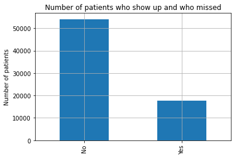

```python
# plot the information about how many patients attend and who didn't
# No : Meaning the patient attend , Yes: Meaning the pateint didn't attend
df['no_show'].value_counts().plot(kind = 'bar')
plt.title('Number of patients who show up and who missed')
plt.ylabel('Number of patients');
plt.grid()
```

```python
missed = df[noshow].shape[0]/df['no_show'].shape[0] * 100
attend = df[show].shape[0]/df['no_show'].shape[0] * 100
```

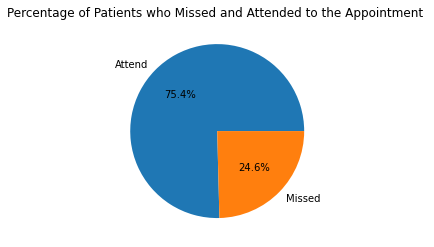

```python
plt.title('Percentage of Patients who Missed and Attended to the Appointment ')
percentage  = [attend,missed]
labels = ['Attend','Missed']
plt.pie(percentage, labels = labels, autopct='%1.1f%%');
```

- The percentage of patients that attend the appointment is 75.4%
- The percentage of patients that missed the appointment is 24.6%

### Research Question 2 (How many patients attend missed the appointment according to the gender?)

### Number of males and females that attend the appointment

```python
df[show].gender.value_counts()
```

```
F    34914
M    19143
Name: gender, dtype: int64
```

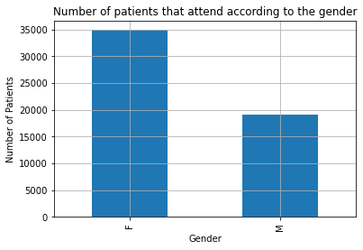

```python
# plot the information about how many patients attend according to the gender
df[show].gender.value_counts().plot(kind = 'bar');
plt.title('Number of patients that attend according to the gender')
plt.xlabel('Gender')
plt.ylabel('Number of Patients');
plt.grid()
```

### Number of males and females who missed the appointment

```python
df[noshow].gender.value_counts()
```

```
F    11489
M     6143
Name: gender, dtype: int64
```

- There is 11489 Females missed the appointment and 6143 Males

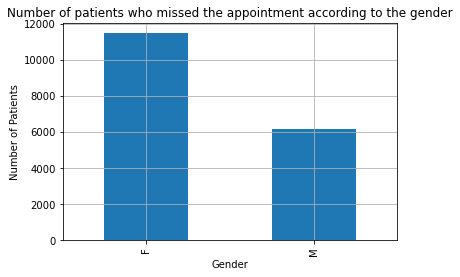

```python
# plot the information about how many patients who didn't attend according to the gender
df[noshow].gender.value_counts().plot(kind = 'bar')
plt.title('Number of patients who missed the appointment according to the gender')
plt.xlabel('Gender')
plt.ylabel('Number of Patients');
plt.grid()
```

```python
males = df[noshow].gender.value_counts()[1]/df['no_show'].shape[0] * 100
females = df[noshow].gender.value_counts()[0]/df['no_show'].shape[0] * 100
print("The percentage of males patients that missed the appointment is {}\nThe percentage of females patients that missed the appointment is {} ".format(males,females))
```

```
The percentage of males patients that missed the appointment is 8.56895758066091
The percentage of females patients that missed the appointment is 16.026168589323326
```

### Research Question 3 (Which age is the most common for showing up and for missing the appointments according to the gender?)

[figure not shown]

```python
# plot the information about which age is the most common for showing up according to the gender
def attend(gender):
    df[show].query('gender ==@ gender').age.hist();
    plt.title('Most common age males and females who attend the appointment')
    plt.xlabel('Age')
    plt.ylabel('Number of Patients')
    labels = ['Female','Male']
    plt.legend(labels)
fil('F')
fil('M')
```

In this graph we can see the most age attending for Males is group ~(0 - 10) and the most age attending for Females is group ~(50 - 58)¶

[figure not shown]

```python
# plot the information about which age is the most common for missing the appointment according to the gender
def missed(gender):
    df[noshow].query('gender ==@ gender').age.hist();
    plt.title('Most common age males and females who missed the appointment')
    plt.xlabel('Age')
    plt.ylabel('Number of Patients')
    labels = ['Female','Male']
    plt.legend(labels)
fil('F')
fil('M')
```

As we see here the most age didn't attend for Males is group ~(0 - 10) and the most age didn't attend for Females is group ~(22 - 27)

### Research Question 4 (What factors are important for us to know in order to predict if a patient will show up for their scheduled appointment?)

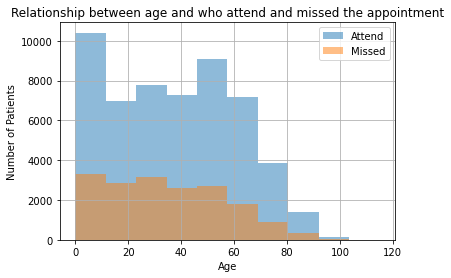

```python
#Plotting relationship between age and who attend and missed the appointment
plt.title('Relationship between age and who attend and missed the appointment')
df[show].age.hist(label = 'Attend',alpha = 0.5)
df[noshow].age.hist(label = 'Missed',alpha = 0.5)
plt.xlabel('Age')
plt.ylabel('Number of Patients')
plt.legend();
```

- We see here that the patients who attend at all ages more than patients who don't attend. So this is not a factor.

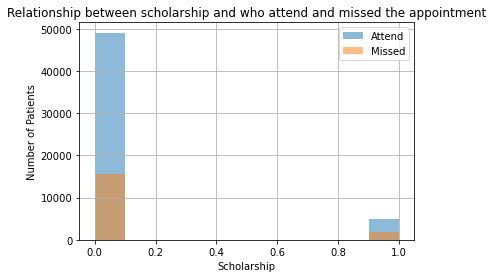

```python
#Plotting relationship between scholarship and who attend and missed the appointment
plt.title('Relationship between scholarship and who attend and missed the appointment')
df[show].scholarship.hist(label = 'Attend',alpha = 0.5)
df[noshow].scholarship.hist(label = 'Missed',alpha = 0.5)
plt.xlabel('Scholarship')
plt.ylabel('Number of Patients')
plt.legend();
```

- We see here that the patients who don't have scholarship attend more than the scholarship patients. So this is not a factor.

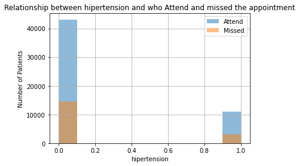

```python
#plotting relationship between hipertension and who Attend and missed the appointment
plt.title('Relationship between hipertension and who Attend and missed the appointment')
df[show].hipertension.hist(label = 'Attend',alpha = 0.5)
df[noshow].hipertension.hist(label = 'Missed',alpha = 0.5)
plt.xlabel('hipertension')
plt.ylabel('Number of Patients')
plt.legend();
```

- We see here that the patients who don't have hipertension attend more than the hipertension patients. So this is not a factor.

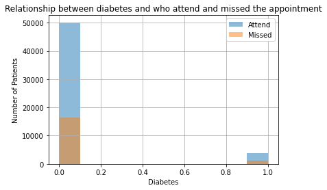

```python
#Plotting relationship between diabetes and who attend and missed the appointment
plt.title('Relationship between diabetes and who attend and missed the appointment')
df[show].diabetes.hist(label = 'Attend',alpha = 0.5)
df[noshow].diabetes.hist(label = 'Missed',alpha = 0.5)
plt.xlabel('Diabetes')
plt.ylabel('Number of Patients')
plt.legend();
```

- We see here that the patients who don't have diabetes attend more than the diabetes patients. So this is not a factor.

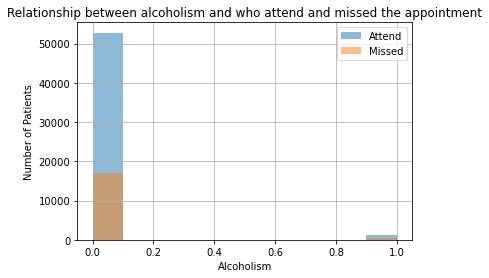

```python
#Plotting relationship between alcoholism and who attend and missed the appointment
plt.title('Relationship between alcoholism and who attend and missed the appointment')
df[show].alcoholism.hist(label = 'Attend',alpha = 0.5)
df[noshow].alcoholism.hist(label = 'Missed',alpha = 0.5)
plt.xlabel('Alcoholism')
plt.ylabel('Number of Patients')
plt.legend();
```

- We see here that the patients who is not alcoholism attend more than the alcoholism patients. So this is not a factor.

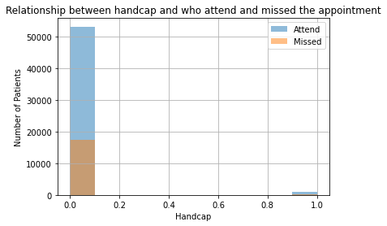

```python
#Plotting relationship between handcap and who attend and missed the appointment
plt.title('Relationship between handcap and who attend and missed the appointment')
df[show].handcap.hist(label = 'Attend',alpha = 0.5)
df[noshow].handcap.hist(label = 'Missed',alpha = 0.5)
plt.xlabel('Handcap')
plt.ylabel('Number of Patients')
plt.legend();
```

- We see here that the patients who is not handcap attend more than the handcap patients. So this is not a factor.

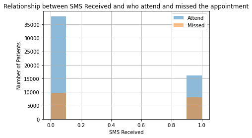

```python
#Plotting erelationship between SMS Received and who attend and missed the appointment
plt.title('Relationship between SMS Received and who attend and missed the appointment')
df[show].sms_received.hist(label = 'Attend',alpha = 0.5)
df[noshow].sms_received.hist(label = 'Missed',alpha = 0.5)
plt.xlabel('SMS Received')
plt.ylabel('Number of Patients')
plt.legend();
```

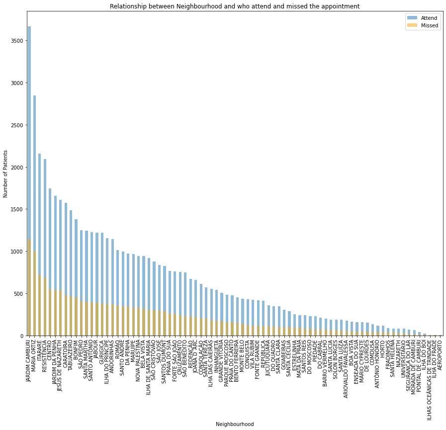

```python
#Plotting relationship between Neighbourhood and who attend and missed the appointment
plt.figure(figsize = (15,12))
plt.title('Relationship between Neighbourhood and who attend and missed the appointment')
df[show].neighbourhood.value_counts().plot(kind = 'bar', label = 'Attend',alpha = 0.5)
df[noshow].neighbourhood.value_counts().plot(kind = 'bar',label = 'Missed',alpha = 0.5, color = 'orange')
plt.xlabel('Neighbourhood')
plt.ylabel('Number of Patients')
plt.legend();
```

- As we see here in the graph It's seems that neighbourhood is a factor for attending and missing the appointments

## Conclusions

#### Limitations:

- There is some wrong data such as age is less than 0.
- The Handcap column had a values greater than 1, which meant that it must contain the values 0 (False) or 1 (True), so we removed them.